# Lecture 3: Data Manipulation with `dplyr`

Harris Coding Camp – Accelerated Track

Summer 2022

# Review

# `dplyr`

# Data manipulation with `dplyr`

The `dplyr` library provides a toolkit for data manipulation.

We will cover:

- `select()` to pick columns
- `filter()` to get rows that meet a criteria
- `arrange()` to order the data
- `mutate()` to create new columns
- `summarize()` to summarize data

# `tidyverse` origins: `dplyr`

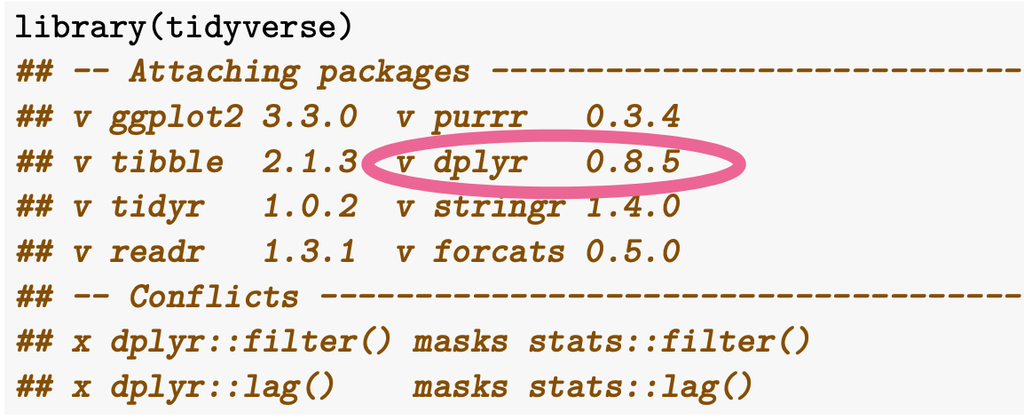

# `dplyr` concepts

For each function:

- data in the first position
- `...` in the second position (i.e. allows for many changes at once)

# selecting columns with `select()`

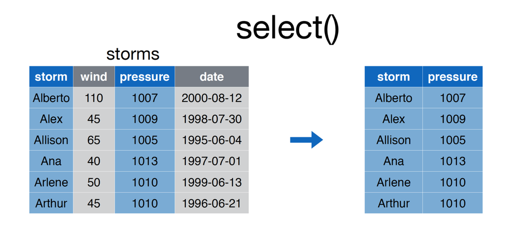

# selecting columns with `select()`

Use case: You want to present a subset of your **columns**

```r
select(texas_housing_data, city, date, sales, listings)
```

```
## # A tibble: 8,602 × 4
##    city     date sales listings
##    <chr>   <dbl> <dbl>    <dbl>
##  1 Abilene 2000     72      701
##  2 Abilene 2000.    98      746
##  3 Abilene 2000.   130      784
##  4 Abilene 2000.    98      785
##  5 Abilene 2000.   141      794
##  6 Abilene 2000.   156      780
##  7 Abilene 2000.   152      742
##  8 Abilene 2001.   131      765
##  9 Abilene 2001.   104      771
## 10 Abilene 2001.   101      764
## # … with 8,592 more rows
```

# `select()` extends `[`

`select` provides a suite of short cuts for selecting columns.

- Notice that `select` can operate with column names while `[` requires Characters.

```r
identical(
  select(texas_housing_data, city, date, sales, listings),
  texas_housing_data[c("city", "date", "sales", "listings")],
)
```

```
## [1] TRUE
```

# selecting columns with `select()`

As with `[`, `-` says to exclude the columns listed in the vector.

```r
select(texas_housing_data, -c(city, date, sales, listings))
```

# selecting columns with `select()`

Use case: I want a bunch of columns with similar names.

- There are several useful functions, see `?tidyselect::select_helpers`.
- (For more information see r4ds chapter 5.4)

```r
# BaseR requires more coding knowledge
# texas_housing_data[,grep("^city", names(texas_housing_data))]

select(texas_housing_data, starts_with("city"))
```

```
## # A tibble: 8,602 × 1
##    city
##    <chr>
##  1 Abilene
##  2 Abilene
##  3 Abilene
##  4 Abilene
##  5 Abilene
##  6 Abilene
##  7 Abilene
##  8 Abilene
##  9 Abilene
## 10 Abilene
## # … with 8,592 more rows
```

# selecting columns with `select()`, helpers

Use case: You want to reorder your columns

- Notice we used a “select_helpers” function `everything()`.

```r
select(texas_housing_data,
       date, everything())
```

```
## # A tibble: 8,602 × 9
##     date city     year month sales   volume median listings inventory
##    <dbl> <chr>   <int> <int> <dbl>    <dbl>  <dbl>    <dbl>     <dbl>
##  1 2000  Abilene  2000     1    72  5380000  71400      701       6.3
##  2 2000. Abilene  2000     2    98  6505000  58700      746       6.6
##  3 2000. Abilene  2000     3   130  9285000  58100      784       6.8
##  4 2000. Abilene  2000     4    98  9730000  68600      785       6.9
##  5 2000. Abilene  2000     5   141 10590000  67300      794       6.8
##  6 2000. Abilene  2000     6   156 13910000  66900      780       6.6
##  7 2000. Abilene  2000     7   152 12635000  73500      742       6.2
##  8 2001. Abilene  2000     8   131 10710000  75000      765       6.4
##  9 2001. Abilene  2000     9   104  7615000  64500      771       6.5
## 10 2001. Abilene  2000    10   101  7040000  59300      764       6.6
## # … with 8,592 more rows
```

# choose rows that match a condition with `filter()`

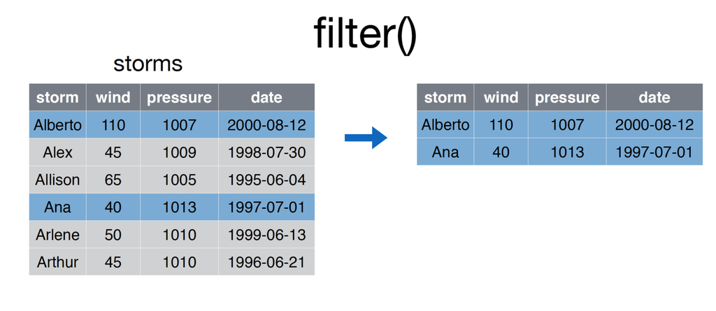

# choose rows that match a condition with `filter()`

Get all the data from 2013

```r
filter(texas_housing_data, year == 2013)
```

```
## # A tibble: 552 × 9
##    city     year month sales   volume median listings inventory  date
##    <chr>   <int> <int> <dbl>    <dbl>  <dbl>    <dbl>     <dbl> <dbl>
##  1 Abilene  2013     1   114 15794494 125300      966       5.7 2013
##  2 Abilene  2013     2   140 16552641  94400      943       5.6 2013.
##  3 Abilene  2013     3   164 19609711 102500      958       5.7 2013.
##  4 Abilene  2013     4   213 27261796 113700      948       5.5 2013.
##  5 Abilene  2013     5   225 31901380 130000      923       5.3 2013.
##  6 Abilene  2013     6   209 29454125 127300      960       5.5 2013.
##  7 Abilene  2013     7   218 32547446 140000      969       5.4 2014.
##  8 Abilene  2013     8   236 30777727 120000      976       5.4 2014.
##  9 Abilene  2013     9   195 26237106 127500      985       5.4 2014.
## 10 Abilene  2013    10   167 21781187 119000      993       5.5 2014.
## # … with 542 more rows
```

# `filter()` extends `[`

```r
identical(
  filter(texas_housing_data, year == 2013),
  texas_housing_data[texas_housing_data$year == 2013, ]
)
```

```
## [1] TRUE
```

Notice that `filter` can operate with column names while `[` requires that you use a vector.

# `filter()` drops comparisons that result in `NA`

Compare:

```r
df <- tibble(x = c(1, 2, NA))
filter(df, x > 1)
```

```
## # A tibble: 1 × 1
##       x
##   <dbl>
## 1     2
```

```r
df[df$x > 1, ]
```

```
## # A tibble: 2 × 1
##       x
##   <dbl>
## 1     2
## 2    NA
```

# Recall: Relational operators return TRUE or FALSE

Before moving forward with `filter()`, let’s review relational operators and logical operators

| Operator | Name |
| --- | --- |
| < | less than |
| > | greater than |
| <= | less than or equal to |
| >= | greater than or equal to |
| == | equal to |
| != | not equal to |
| %in% | matches something in |

# Recall: Relational operators in practice

```r
4 < 4
```

```
## [1] FALSE
```

```r
4 >= 4
```

```
## [1] TRUE
```

```r
4 == 4
```

```
## [1] TRUE
```

```r
4 != 4
```

```
## [1] FALSE
```

```r
4 %in% c(1, 2, 3)
```

```
## [1] FALSE
```

# `%in%` operator

Tests if left-hand side is in right-hand side.

```r
# 1 %in% c(1, 2, 3, 4)  TRUE
# 5 %in% c(1, 2, 3, 4)  FALSE
c(1, 5) %in% c(1, 2, 3, 4)
```

```
## [1]  TRUE FALSE
```

It operates *element-by-element* on the left-hand side!

# Review: logical operators combine TRUEs and FALSEs logically

| Operator | Name |
| --- | --- |
| ! | not |
| & | and |
| `\|` | or |

```r
# not true
! TRUE
```

```
## [1] FALSE
```

```r
# are both x & y TRUE?
TRUE  &  FALSE
```

```
## [1] FALSE
```

```r
# is either x | y TRUE?
TRUE | FALSE
```

```
## [1] TRUE
```

# Review: What do the following return?

```r
! (4 > 3)
(5 > 1) & (5 > 2)
(4 > 10) | (20 > 3)
```

# Review: What do the following return?

Logical operators team up with relational operators.

- First, evaluate the relational operator
- Then, carry out the logic.

```r
! (4 > 3)             # ! TRUE
(5 > 1) & (5 > 2)     # TRUE & TRUE
(4 > 10) | (20 > 3)   # FALSE | TRUE
```

# Recall: What do the following return?

```r
! (4 > 3)             # ! TRUE
```

```
## [1] FALSE
```

```r
(5 > 1) & (5 > 2)     # TRUE & TRUE
```

```
## [1] TRUE
```

```r
(4 > 10) | (20 > 3)   # FALSE | TRUE
```

```
## [1] TRUE
```

# choose rows that match a condition with `filter()`

Get all the data from 2013 and beyond for Houston.

- in `filter()` additional match criteria are treated like `and`

```r
  filter(texas_housing_data,
         year >= 2013,
         city == "Houston")
```

```
## # A tibble: 31 × 9
##    city     year month sales     volume median listings inventory  date
##    <chr>   <int> <int> <dbl>      <dbl>  <dbl>    <dbl>     <dbl> <dbl>
##  1 Houston  2013     1  4273  852045057 149500    21364       3.7 2013
##  2 Houston  2013     2  4886 1060985674 161900    21293       3.6 2013.
##  3 Houston  2013     3  6382 1479273481 172300    20909       3.5 2013.
##  4 Houston  2013     4  7116 1770746764 182400    20607       3.4 2013.
##  5 Houston  2013     5  8439 2121508529 186100    20526       3.3 2013.
##  6 Houston  2013     6  7935 2073909387 191600    21008       3.3 2013.
##  7 Houston  2013     7  8468 2168720825 187800    21497       3.3 2014.
##  8 Houston  2013     8  8155 2083377894 186700    21366       3.3 2014.
##  9 Houston  2013     9  6706 1638923780 180200    21207       3.2 2014.
## 10 Houston  2013    10  6551 1544551772 176000    20508       3.1 2014.
## # … with 21 more rows
```

# choose rows that match a condition with `filter()`

To do the same operation with `[` …

```r
identical(
  filter(texas_housing_data,
         year >= 2013,
         city == "Houston"),

texas_housing_data[texas_housing_data$year >= 2013 &
                   texas_housing_data$city == "Houston", ]
)
```

```
## [1] TRUE
```

# Why do we get 0 rows here?

Get all the data from 2013 and beyond for Houston and Austin

```r
  filter(texas_housing_data,
         year >= 2013,
         city == "Houston",
         city == "Austin")
```

```
## # A tibble: 0 × 9
## # … with 9 variables: city <chr>, year <int>, month <int>, sales <dbl>,
## #   volume <dbl>, median <dbl>, listings <dbl>, inventory <dbl>, date <dbl>
```

# choose rows that match a condition with `filter()`

There’s no rows that cover Houston AND Austin!

We logically want data from Houston OR Austin

```r
  filter(texas_housing_data,
         year >= 2013,
         city == "Houston" | city == "Austin")
```

```
## # A tibble: 62 × 9
##    city    year month sales    volume median listings inventory  date
##    <chr>  <int> <int> <dbl>     <dbl>  <dbl>    <dbl>     <dbl> <dbl>
##  1 Austin  2013     1  1566 402135669 199200     5548       2.6 2013
##  2 Austin  2013     2  1795 468527290 206800     5752       2.6 2013.
##  3 Austin  2013     3  2384 661274904 217100     5848       2.6 2013.
##  4 Austin  2013     4  2692 820141712 227300     6121       2.7 2013.
##  5 Austin  2013     5  3182 944924177 228100     6424       2.8 2013.
##  6 Austin  2013     6  2970 880058970 234100     6724       2.9 2013.
##  7 Austin  2013     7  3376 993168216 227900     6721       2.8 2014.
##  8 Austin  2013     8  3318 931481472 218800     6706       2.7 2014.
##  9 Austin  2013     9  2544 725959392 224000     6569       2.6 2014.
## 10 Austin  2013    10  2350 648747783 218300     6114       2.4 2014.
## # … with 52 more rows
```

# choose rows that match a condition with `filter()`

At some point you will make this mistake!

```r
  filter(texas_housing_data,
         year >= 2013,
         city == "Houston" | "Austin")
```

```
Error in filter(texas_housing_data, year >= 2013, city == "Houston" | :
Caused by error in `city == "Houston" | "Austin"`:
! operations are possible only for numeric, logical or complex types
```

# choose rows that match a condition with `filter()`

What if we want data from Houston, Austin OR Galveston

```r
  filter(texas_housing_data,
         year >= 2013,
         city == "Houston" | city == "Austin" | city == "Galveston")
```

There has to be an easier way!

# choose rows that match a condition with `filter()`

Use `%in%`!

```r
  in_three_cities <-
    filter(texas_housing_data,
          year >= 2013,
          city %in% c("Houston", "Dallas", "Austin"))
```

# Warning: `==` with two vectors is a bad idea.

Why does it fail to produce the same result?

```r
eq_three_cities <-
      filter(texas_housing_data,
             year >= 2013,
             city == c("Houston", "Dallas", "Austin"))
```

```
## Warning in city == c("Houston", "Dallas", "Austin"): longer object length is not
## a multiple of shorter object length
```

```r
identical(in_three_cities, eq_three_cities)
```

```
## [1] FALSE
```

```r
nrow(in_three_cities)
```

```
## [1] 93
```

```r
nrow(eq_three_cities)
```

```
## [1] 30
```

# Warning: `==` with two vectors is a bad idea.

Why not? Vector recycling.

```r
ex <- tibble(id = 1:4,
       attribute = c("a", "a", "b", "b"))

filter(ex,
       attribute == c("a", "c"))
```

```
## # A tibble: 1 × 2
##      id attribute
##   <int> <chr>
## 1     1 a
```

# Warning: `==` with two vectors is a bad idea.

Why not? Vector recycling.

```r
# a == a
# a == c
# b == a
# b == c

filter(ex, attribute == c("a", "c"))
```

```
## # A tibble: 1 × 2
##      id attribute
##   <int> <chr>
## 1     1 a
```

# Crisis averted

```r
# a %in% c(a, c)
# a %in% c(a, c)
# b %in% c(a, c)
# b %in% c(a, c)

filter(ex, attribute %in% c("a", "c"))
```

```
## # A tibble: 2 × 2
##      id attribute
##   <int> <chr>
## 1     1 a
## 2     2 a
```

# Introducing the pipe operator

# Interlude: Ceci est une `%>%`

The pipe `%>%` operator takes the left-hand side and makes it *input* in the right-hand side.

- by default, the left-hand side is the *first argument* of the right-hand side function.

```r
# a tibble is the first argument
select(texas_housing_data, city, year, sales, volume)

texas_housing_data %>%
  select(city, year, sales, volume)
```

# Ceci est une `%>%`

We can chain together tidyverse functions to avoid making so many intermediate data frames!

- Coming up with names is hard.
- Updating an object repeatedly leads to a buggy development process

```r
texas_housing_data %>%
  select(city, year, month, median) %>%
  arrange(desc(median))
```

```
## # A tibble: 8,602 × 4
##    city           year month median
##    <chr>         <int> <int>  <dbl>
##  1 Collin County  2015     5 304200
##  2 Collin County  2015     6 300400
##  3 Collin County  2015     7 292600
##  4 Collin County  2015     4 291400
##  5 Collin County  2015     3 285800
##  6 Fort Bend      2015     6 284200
##  7 Collin County  2015     2 283400
##  8 Midland        2014     6 283100
##  9 Fort Bend      2014     6 282300
## 10 Fort Bend      2015     7 280400
## # … with 8,592 more rows
```

# sort rows with `arrange()`

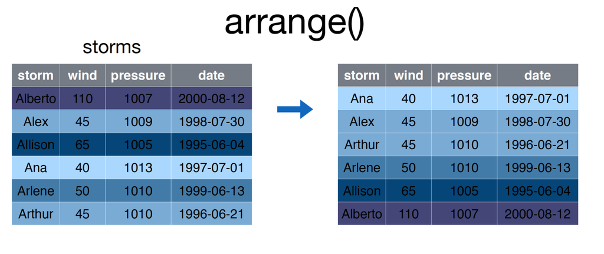

# sort rows with `arrange()`

```r
identical(
  # base R
  texas_housing_data[order(texas_housing_data$year), ],

  # base R
  arrange(texas_housing_data, year)
)
```

```
## [1] TRUE
```

# sort rows with `arrange()`

To sort in `desc()`ending order.

```r
identical(
  # base R
  texas_housing_data[order(texas_housing_data$year,
                           decreasing = TRUE), ],

  # base R
  texas_housing_data %>% arrange(desc(year))
)
```

```
## [1] TRUE
```

# creating columns with `mutate()`

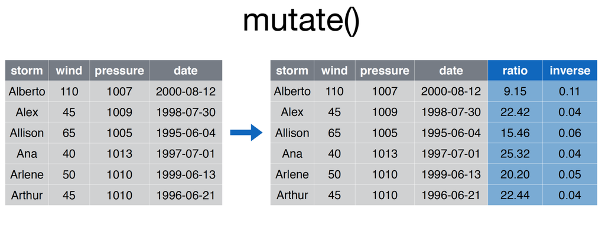

# creating columns with `mutate()`

```r
texas_housing_data %>%
  mutate(mean_price = volume / sales) %>%
  select(city, year, month,  mean_price, sales, volume)
```

```
## # A tibble: 8,602 × 6
##    city     year month mean_price sales   volume
##    <chr>   <int> <int>      <dbl> <dbl>    <dbl>
##  1 Abilene  2000     1     74722.    72  5380000
##  2 Abilene  2000     2     66378.    98  6505000
##  3 Abilene  2000     3     71423.   130  9285000
##  4 Abilene  2000     4     99286.    98  9730000
##  5 Abilene  2000     5     75106.   141 10590000
##  6 Abilene  2000     6     89167.   156 13910000
##  7 Abilene  2000     7     83125    152 12635000
##  8 Abilene  2000     8     81756.   131 10710000
##  9 Abilene  2000     9     73221.   104  7615000
## 10 Abilene  2000    10     69703.   101  7040000
## # … with 8,592 more rows
```

# Binary operators: Math in R

R is a calculator! We can do math with numbers, using the following symbols:

```r
4 + 4
4 - 4
4 * 4
4 / 4
4 ^ 4
5 %% 4  # gives the remainder after dividing
```

# creating columns with `mutate()`

When we mutate, you can create new columns.

```r
texas_housing_data %>%
  mutate(mean_price = volume / sales) %>%
  select(city, year, month,  mean_price, sales, volume)
```

```
## # A tibble: 8,602 × 6
##    city     year month mean_price sales   volume
##    <chr>   <int> <int>      <dbl> <dbl>    <dbl>
##  1 Abilene  2000     1     74722.    72  5380000
##  2 Abilene  2000     2     66378.    98  6505000
##  3 Abilene  2000     3     71423.   130  9285000
##  4 Abilene  2000     4     99286.    98  9730000
##  5 Abilene  2000     5     75106.   141 10590000
##  6 Abilene  2000     6     89167.   156 13910000
##  7 Abilene  2000     7     83125    152 12635000
##  8 Abilene  2000     8     81756.   131 10710000
##  9 Abilene  2000     9     73221.   104  7615000
## 10 Abilene  2000    10     69703.   101  7040000
## # … with 8,592 more rows
```

# creating columns with `mutate()`

You can create multiple columns at a single time and even use information from a newly created column as input.

```r
texas_housing_data %>%
  mutate(mean_price = volume / sales,
         sqrt_mean_price = sqrt(mean_price)) %>%
  select(city, year, month,  mean_price, sales, volume)
```

```
## # A tibble: 8,602 × 6
##    city     year month mean_price sales   volume
##    <chr>   <int> <int>      <dbl> <dbl>    <dbl>
##  1 Abilene  2000     1     74722.    72  5380000
##  2 Abilene  2000     2     66378.    98  6505000
##  3 Abilene  2000     3     71423.   130  9285000
##  4 Abilene  2000     4     99286.    98  9730000
##  5 Abilene  2000     5     75106.   141 10590000
##  6 Abilene  2000     6     89167.   156 13910000
##  7 Abilene  2000     7     83125    152 12635000
##  8 Abilene  2000     8     81756.   131 10710000
##  9 Abilene  2000     9     73221.   104  7615000
## 10 Abilene  2000    10     69703.   101  7040000
## # … with 8,592 more rows
```

# summarize data with `summarize()`

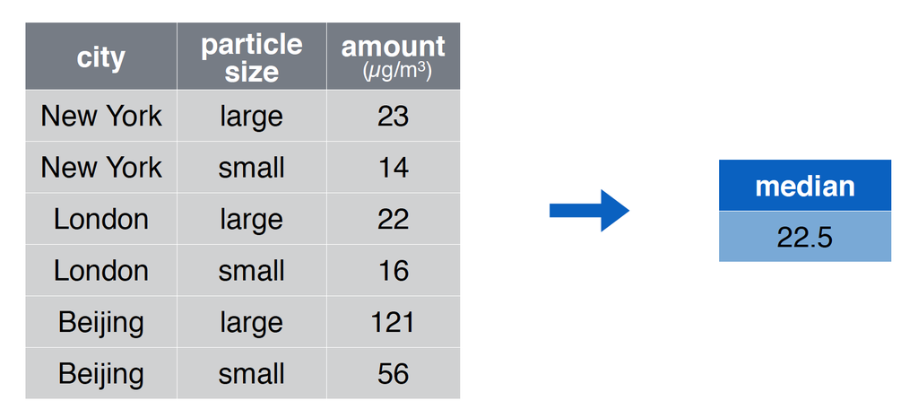

# summarize data with `summarize()`

Calculate total volume of sales in Texas from 2014.

```r
texas_housing_data %>%
  filter(year == 2014) %>%
  summarize(total_volume = sum(volume))
```

```
## # A tibble: 1 × 1
##   total_volume
##          <dbl>
## 1  84760948831
```

# summarize data with `summarize()`

Calculate the mean and median number of sales in Texas’s three largest cities.

```r
texas_housing_data %>%
  filter(city %in%
           c("Houston", "Dallas", "San Antonio")) %>%
  summarize(median_n_sales = median(sales),
            mean_n_sales = mean(sales))
```

```
## # A tibble: 1 × 2
##   median_n_sales mean_n_sales
##            <dbl>        <dbl>
## 1           3996        3890.
```

# summarize data with `summarize()`

There are many useful functions that go with summarize. Try `?summarize` for more.

```r
texas_housing_data %>%
  filter(city %in%
           c("Houston", "Dallas", "San Antonio")) %>%
  summarize(n_obs = n(),
            n_cities = n_distinct(city))
```

```
## # A tibble: 1 × 2
##   n_obs n_cities
##   <int>    <int>
## 1   561        3
```

# summarize data with `summarize()`

If you try to make a summarize statistic that does not collapse the data to a single value (per group), you’ll get an error like so:

```r
texas_housing_data %>%
  filter(city %in%
           c("Houston", "Dallas", "San Antonio")) %>%
  summarize(mean_price = volume / sales)

Error: Column `mean_price` must be length 1 (a summary value), not 561
```

# piping `dplyr` verbs together

`dplyr`verbs can be piped together in any order you want, although different orders can give you different results, so be careful!

```r
texas_housing_data %>%
  select(city, year, month, sales, volume) %>%
  mutate(log_mean_price = log(volume / sales)) %>%
  filter(year == 2013) %>%
  summarize(log_mean_price_2013 = mean(log_mean_price,
                                       na.rm = TRUE))
```

```
## # A tibble: 1 × 1
##   log_mean_price_2013
##                 <dbl>
## 1                12.1
```

```r
# Won't give you the same result as
# texas_housing_data %>%
 #  select(city, year, month, sales, volume) %>%
 #  mutate(log_mean_price = log(volume / sales)) %>%
 #  summarize(log_mean_price = mean(log_mean_price, na.rm = TRUE)) %>%
 #  filter(year == 2013)

# Actually this code will give you an error, try it!
```

# Recap: manipulating data with `dplyr`

We learned

- how to employ the 5 `dplyr` verbs of highest importance including
  - `select()` to pick columns
  - `arrange()` to order the data
  - `mutate()` to create new columns
  - `filter()` to get rows that meet a criteria
  - `summarize()` to summarize data
- how to use relation operators, binary operators for math and logical operators in `dplyr` contexts
[^1]: more on vectors in the next lesson